# Breaking the Silence: An Examination of Indonesian Young Girls’ Reproductive Decision-Making

Muthia Huda Islami

Indonesia is well-known as a country with most of majority as muslims which also has a culture that is somehow partly affected by religious values. This includes sex before marriage and its taboos. It renders most schools to overlook the importance of sex education and highlight more on abstinence. **But has this been effective? Is it the right answer, especially with a vast amount of media that surrounds us, including teenage girls, to overcome the early pregnancy issues and also sexually transmitted infections?**

This report shows numerous of data that illustrates the Indonesian teenage girls decisions in reproductive lifestyle in Jakarta, which is one of the most populated province in Indonesia.

### First, where did this data come from?

Firstly, a questionnaire by Demographic and Health Survey (DHS) regarding reproductive health was asked to girls and women across Indonesia as illustrated in the two graphs below.

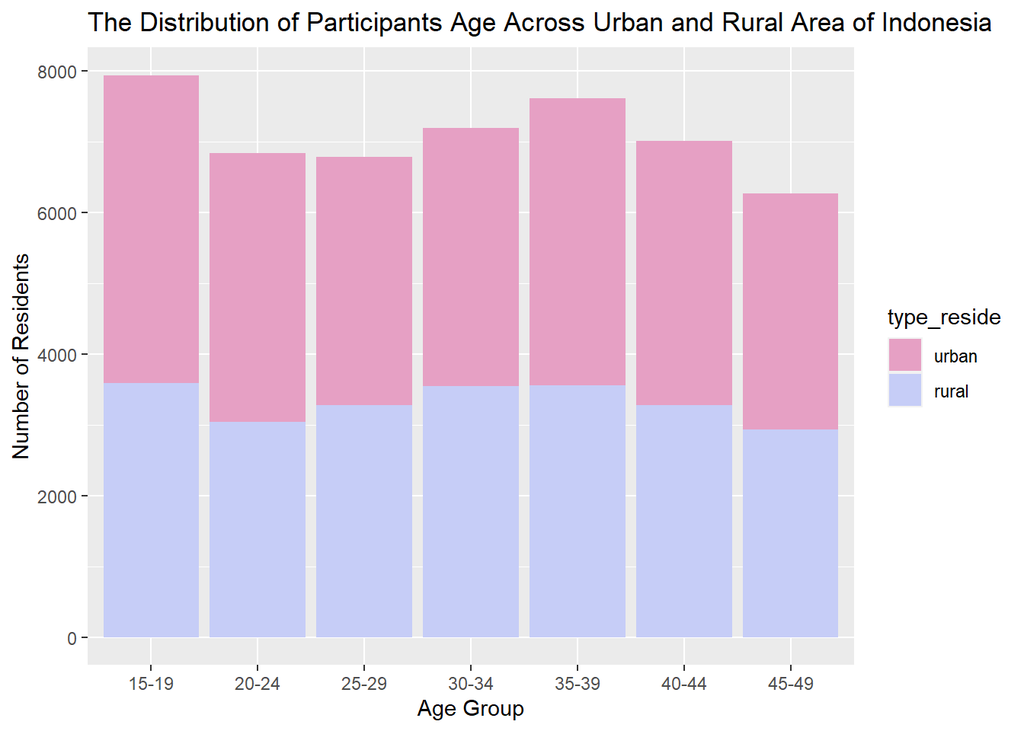

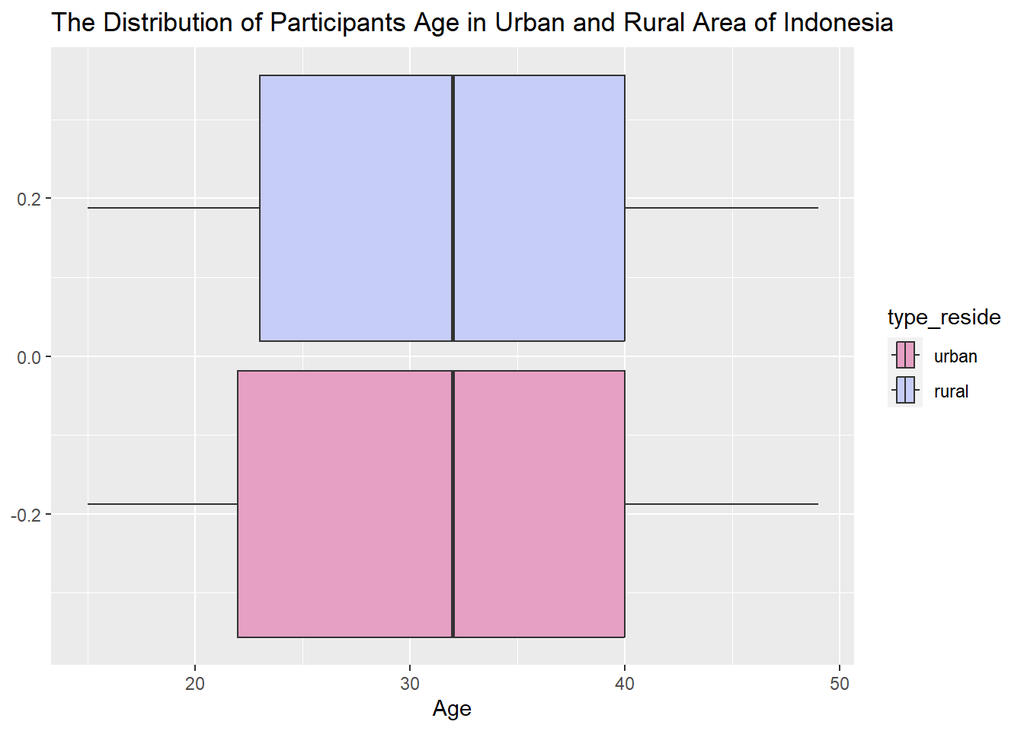

As you can see in the graph above, the study participants mostly came from **Urban area** with the mean age of **31.5845608 year-old**.

The graph below also shows the distributions of highest education and age among the questionnaire participants.

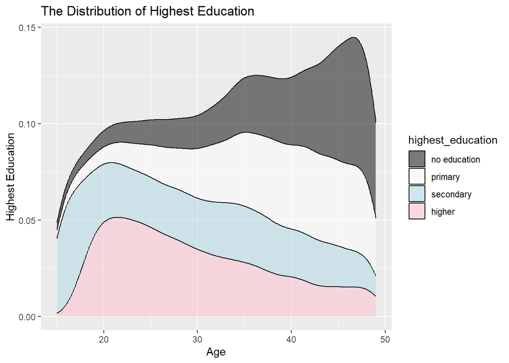

### A look to the Indonesian young girls demographic profile of our participants

The data shown before from Indonesia. We filtered the data further into those who were filled by young girls aged less than 25 years old in Jakarta.

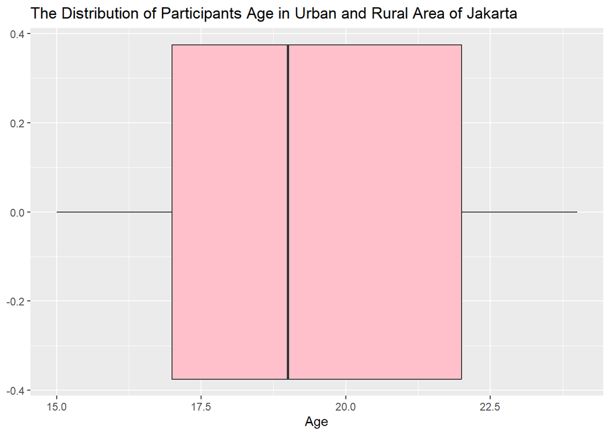

The majority of the participants, which accounts for **540** participants, lived in urban area and with the mean age of **19.2092593** years-old. Because Jakarta comprises of residents with various socioeconomic status, we also observe the literacy status of the participants as illustrated below. *All of them could read whole sentence.*

| Literacy Status | Frequency |
| --- | --- |
| cannot read at all | 0 |
| able to read only parts of sentence | 0 |
| able to read whole sentence | 540 |
| blind/visually impaired | 0 |

### Take a dive into Indonesian young girls relationship lifestyle

As mentioned before, Indonesia comprises of majority of muslim. There are approximately 229,000,000 muslims settling in Indonesia, which accounts for 87.2% of its whole population. Islam regulates quite strictly on relationships and sexual activities before marriages. The question is, *does this affect Indonesian teen girls in having relationships?*

The graph below shows that most of young girls across all ages ranging from 15 - 24 year-old have had relationships. However, it is important to note that most of the questionnaire participants did not answer a question about their religion, therefore this graph may also include participants with different religion’s rules (eg: Christian, Buddha, Hindu).

[figure not shown]

The questionnaire further asked the participants who have had relationship regarding their relationship lifestyle that included holding hands, embracing, kissing lips, and touching or arousing partner’s sensitive body parts.

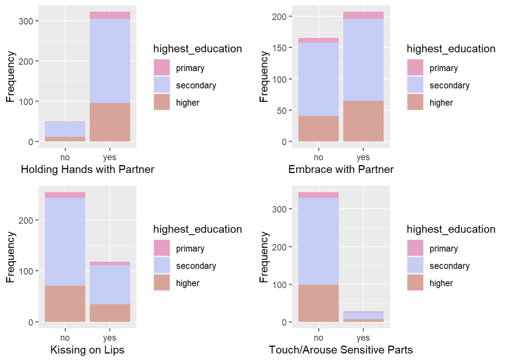

From all the choices answered, most admitted holding hands with their boyfriends, followed by embracing, then kissing on lips and touching/arousing their boyfriends sensitive parts. In addition, most who admitted them were from **secondary educational level**, and despite Indonesian strict culture on sex before marriage, there were a few who admitted ever touching or arousing their partners sensitive parts.

### What about sex before marriage in Jakarta?

We have presented you the data of Indonesian young girls decision in their relationships. But how about sexual intercourse, in which any bigger issue can come from which varies from sexually transmitted infection to young pregnancy and its potential disadvantage for the girls health?

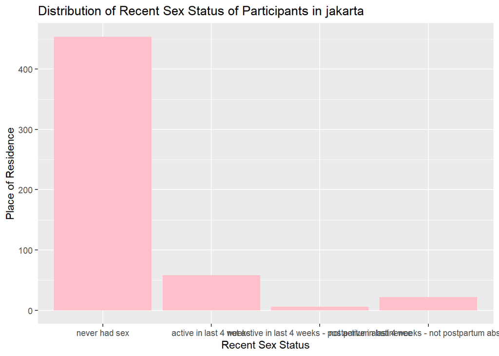

Good news is, most of Jakarta residents aged 15-24 years old admitted never having sex whilst only a few of them considered themselves active in the last 4 weeks. The questionnaire further asked those who have had sex, the reasons for the first sex and the use of pregnancy prevention which results in below graph.

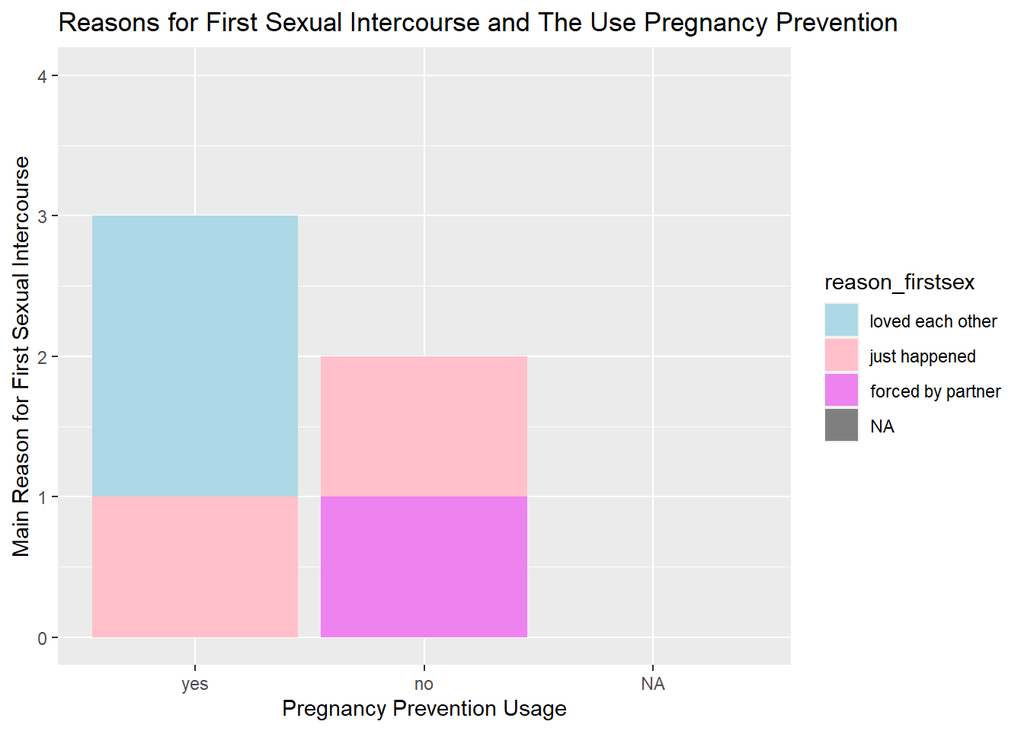

Even though a conclusion cannot be made due to small amount of young girls who have had sex, but this also signifies that most of Indonesian young girls residing in the capital city haven’t had sex at an early age. **But have they been motivated to do so?**

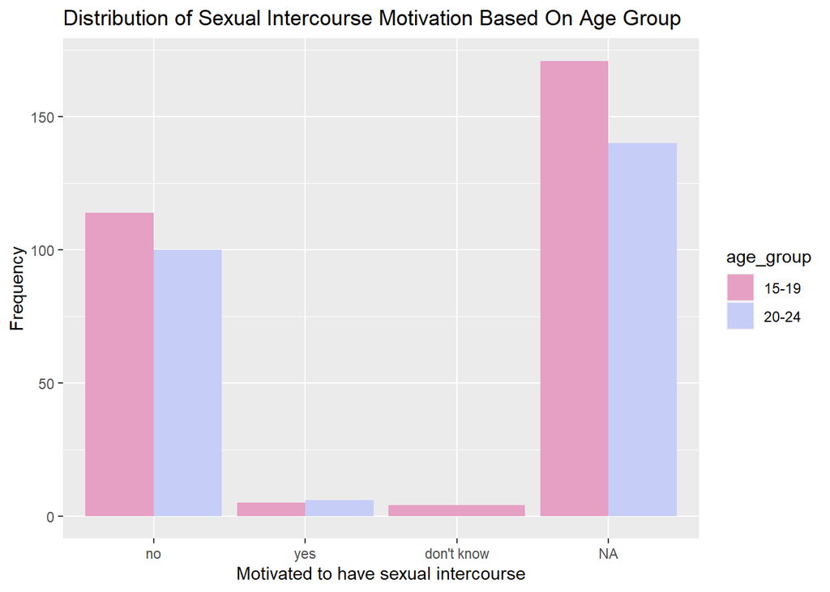

The mean age of those who admitted were motivated to have sexual intercourse is **20.1818182 years old**.

Additionally, the questionnaire also collected their opinions regarding sexual decision-making.

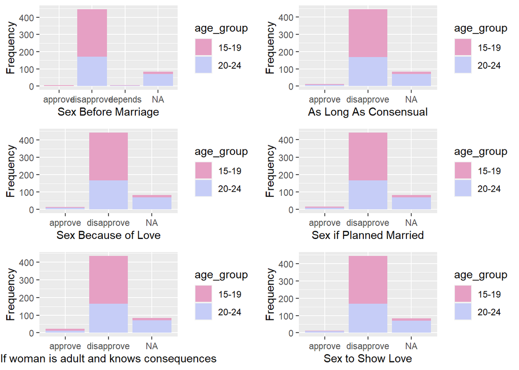

The chart above indicates that most of Indonesian young girls mainly disapproved of sex before marriage no matter the reasons. Furthermore, the questionnaire collected their opinions regarding the importance to be a virgin unti marriage, and it found that most of the Indonesian young girls, regardless of their age group, **strongly agreed to maintain their virginity until marriage**.

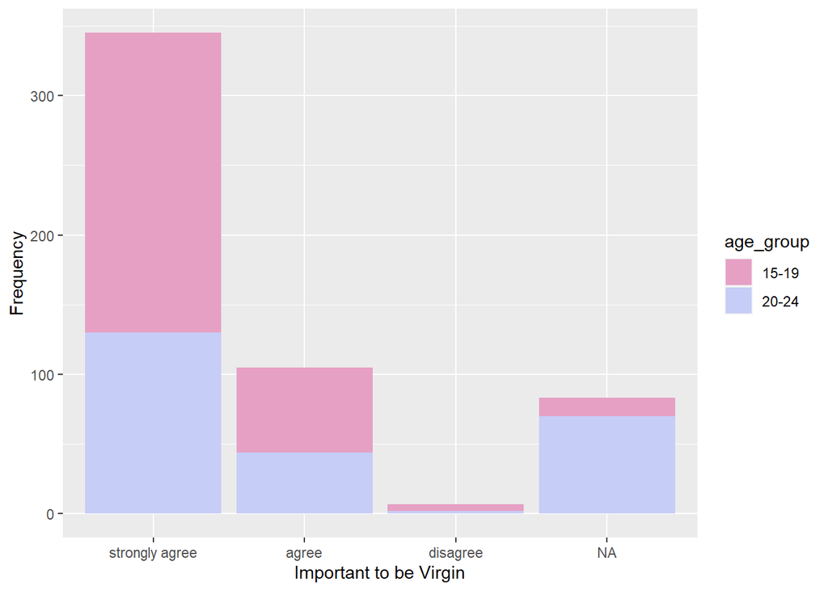

### Early sex education, is it important?

The data illustrated before has shown that despite the easier exposure to sex and nudity in social media and entertainment, Indonesian young girls are still aware of the religion rule to be a virgin until marriage. Nonetheless, most of them still went through romantic relationship with mostly harmless relationship lifestyle *(holding hands, embracing)*, with a few doing a semi-sexual relationship *(touching/arousing sensitive parts)*. This does not exclude that there is a possible shift in relationship decision-making in the next generations, therefore all of the parents and schools still have responsibility to hold early sex education to anticipate such culture shift in young girls, especially teenage girls.

It is also important to note the possible bias in this questionnaire that includes the fear of being judged or memory bias, which may affect the accuracy of the data.